# Study 2: numerical comparisons

This report reads the selected merged paper export by default. It includes all completed fits, including diagnostic warnings. It does not rerun MCMC to render saved results. The source manifest is in `../manifests/study2/`.

## Method comparison

EIV-GP is fitted by our package. UC-GP, LVGP, and EzGP use their respective packages through the package’s comparison adapters. PI-GP and CC-GP are internal ablations. MCSEs describe variation across replications, not within-fit MCMC error.

```r
if(params$action=="report") {
  cat("Selected source:",result$source,"\n\n")
  print(eivGP::report_table(result$summary,caption="Scores and replication MCSEs"))
} else print(result)
```

Selected source: /Users/sheng/Library/CloudStorage/Dropbox/Research/ordinal_mixed_input_GP/study2/runs/recovery-publication-linux/study2

Scores and replication MCSEs

|  | cell_id | method | n_calib | metric | n | mean | mcse |
| --- | --- | --- | --- | --- | --- | --- | --- |
| 1 | primary_q2 | Oracle | NA | RMSE | 50 | 0.330 | 0.004 |
| 2 | primary_q2 | Oracle | NA | CRPS | 50 | 0.180 | 0.002 |
| 3 | primary_q2 | Oracle | NA | Coverage95 | 50 | 0.949 | 0.003 |
| 4 | primary_q2 | Oracle | NA | Width95 | 50 | 1.245 | 0.005 |
| 41 | primary_q2 | EIV-GP | 50 | RMSE | 50 | 0.340 | 0.004 |
| 42 | primary_q2 | EIV-GP | 50 | CRPS | 50 | 0.188 | 0.002 |
| 43 | primary_q2 | EIV-GP | 50 | Coverage95 | 50 | 0.950 | 0.003 |
| 44 | primary_q2 | EIV-GP | 50 | Width95 | 50 | 1.337 | 0.012 |
| 305 | primary_q4_calibration | Oracle | NA | RMSE | 50 | 0.271 | 0.003 |
| 3051 | primary_q4_calibration | Oracle | NA | CRPS | 50 | 0.147 | 0.002 |
| 3052 | primary_q4_calibration | Oracle | NA | Coverage95 | 50 | 0.948 | 0.003 |
| 3053 | primary_q4_calibration | Oracle | NA | Width95 | 50 | 1.028 | 0.004 |
| 308 | primary_q4_calibration | EIV-GP | 0 | RMSE | 50 | 0.306 | 0.004 |
| 3081 | primary_q4_calibration | EIV-GP | 0 | CRPS | 50 | 0.169 | 0.002 |
| 3082 | primary_q4_calibration | EIV-GP | 0 | Coverage95 | 50 | 0.956 | 0.004 |
| 3083 | primary_q4_calibration | EIV-GP | 0 | Width95 | 50 | 1.251 | 0.013 |
| 311 | primary_q4_calibration | EIV-GP | 20 | RMSE | 50 | 0.293 | 0.004 |
| 3111 | primary_q4_calibration | EIV-GP | 20 | CRPS | 50 | 0.161 | 0.002 |
| 3112 | primary_q4_calibration | EIV-GP | 20 | Coverage95 | 50 | 0.956 | 0.004 |
| 3113 | primary_q4_calibration | EIV-GP | 20 | Width95 | 50 | 1.179 | 0.009 |
| 314 | primary_q4_calibration | EIV-GP | 50 | RMSE | 50 | 0.288 | 0.004 |
| 3141 | primary_q4_calibration | EIV-GP | 50 | CRPS | 50 | 0.159 | 0.002 |
| 3142 | primary_q4_calibration | EIV-GP | 50 | Coverage95 | 50 | 0.954 | 0.004 |
| 3143 | primary_q4_calibration | EIV-GP | 50 | Width95 | 50 | 1.141 | 0.009 |
| 317 | primary_q4_calibration | EIV-GP | 80 | RMSE | 50 | 0.285 | 0.004 |
| 3171 | primary_q4_calibration | EIV-GP | 80 | CRPS | 50 | 0.157 | 0.002 |
| 3172 | primary_q4_calibration | EIV-GP | 80 | Coverage95 | 50 | 0.952 | 0.004 |
| 3173 | primary_q4_calibration | EIV-GP | 80 | Width95 | 50 | 1.125 | 0.008 |
| 945 | logistic_q4 | Oracle | NA | RMSE | 50 | 0.268 | 0.003 |
| 9451 | logistic_q4 | Oracle | NA | CRPS | 50 | 0.145 | 0.001 |

[output cut: 78 more lines]

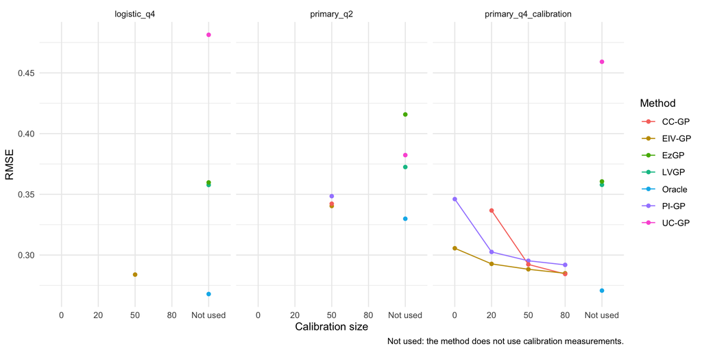

```r
if(params$action=="report") print(eivGP::plot_comparison(result$summary,"RMSE"))
```

## Diagnostics

Passing one diagnostic does not establish convergence for every estimand. No fits are excluded from the score summaries on the basis of diagnostics.

```r
if(params$action=="report") print(eivGP::report_table(eivGP::summarize_diagnostics(result$diagnostics)))
```

|  | cell_id | n_calib | fits | target_functional_pass_count | mcmc_pass_count | predictive_min_bulk_ess | predictive_min_tail_ess | predictive_max_rhat |
| --- | --- | --- | --- | --- | --- | --- | --- | --- |
| 1 | primary_q2 | 50 | 50 | 48 | 2 | 603.007 | 1118.742 | 1.014 |
| 51 | primary_q4_calibration | 0 | 50 | 3 | 0 | 7.284 | 23.433 | 1.518 |
| 52 | primary_q4_calibration | 20 | 50 | 7 | 0 | 28.796 | 148.986 | 1.099 |
| 53 | primary_q4_calibration | 50 | 50 | 44 | 1 | 123.483 | 1287.794 | 1.037 |
| 54 | primary_q4_calibration | 80 | 50 | 49 | 6 | 21.571 | 109.750 | 1.124 |
| 187 | logistic_q4 | 50 | 50 | 49 | 0 | 767.195 | 1568.511 | 1.007 |

## Reproduction

Use `study2.R` for batch execution or change this notebook’s action to `plan`, `data`, `fit`, or `run`. New runs preserve the selected profile’s scientific settings and write to the external results folder. New package identities may produce new run IDs; do not rename old caches to force compatibility.

```
## [1] '0.4.0'
```